# ETH Sustainability Department Visibility Survey

Final report of the Capstone Project

Author

Affiliation

Ana Bendiek Laranjo

[ETH Zurich](https://ethz.ch/de.html)

Published

June 6, 2024

Abstract

This survey aims to assess the visibility and awareness of the ETH Sustainability department among ETH Zurich members. As the central hub for sustainability activities, ETH Sustainability is crucial in advancing sustainable development within the university and in broader society.  
The department oversees various initiatives, including ETH Net Zero activities, sustainability reporting, and various projects related to sustainable travel and gastronomy. Despite its pivotal role, there is limited information on the awareness levels and engagement of the ETH community with these initiatives.  
The survey seeks to understand the current recognition and understanding of ETH Sustainability’s work and services. Specifically, it will explore how well the department’s efforts are known among students, faculty, and staff, and how these stakeholders perceive and engage with its activities. Additionally, the survey will gather insights on potential strategies to enhance the department’s visibility and improve stakeholder engagement. The findings will contribute to the ongoing efforts to integrate sustainability more deeply into the university’s culture and operations, ensuring that ETH Zurich continues to lead in sustainable development.”

# Introduction

Switzerland derives its concept of sustainability from the World Commission on Environment and Development (ARE, n.d.), also known as the Brundtland Commission. In its 1987 report, “Our Common Future,” the Commission defined sustainable development as “Development that satisfies the needs of the present without jeopardizing the ability of future generations to meet their own needs” (Commission mondiale sur l’environnement et le développement, 1991). Based on the 2030 Agenda of 2015 (United Nations, 2015, ¨), the Federal Council adopted Switzerland’s long-term climate strategy on 27 January 2021. In the “Strategie Nachhaltige Entwicklung 2030”, the Confederation undertakes to consistently apply the principles of sustainable development to its own activities and units, which include the ETH Domain, in order to contribute to the achievement of the SDS 2030 goals (ARE, 2021).

Within the organizational structure of ETH Zurich, the Department of Sustainability is the central strategic-operational unit and dedicated to enhancing ETH Zurich’s contribution to sustainable development and communicating these efforts both internally and externally. The unit was established in 2008 and has since initiated numerous groundbreaking projects and processes. Their responsibilty lies in the coordination of the ETH Net Zero activities, manage sustainability reporting, oversee the ETH Air Travel Project and the Sustainable Gastronomy Project, compile the catalogue of sustainability-related lectures, and organize the Public Lecture series “Sustainable Development Goals in Context” in collaboration with ETH4D (*ETH Sustainability*, n.d.). Despite its crucial role in the compliance with climate change targets, there is limited information on the awareness levels and engagement of the ETH community with these initiatives.

The survey seeks to understand the current awareness and understanding of ETH Sustainability’s work and services. Specifically, it will explore how well the department’s efforts are known among members of the ETH domain, and how these stakeholders perceive and engage with its activities. The insights of this study could contribute to improving the department’s visibility and increasing sustainability on campus.

The survey’s main research question is: What is the current level of awareness among ETH members regarding the work of and services provided by the ETH Sustainability department, and how could it be improved?

To answer the main research question, three initial research questions are guiding the study:

- **RQ1:** What is the current level of awareness among ETH members about the ETH Sustainability Department and its work?
- **RQ2:** How visible is the work of the ETH Sustainability Department?
- **RQ3:** What would most effective information channels to increase the visibility of the ETH?

This project is part of the lecture series “151-8102-00L Research Beyond the Lab: Open Science and Research Methods for a Global Engineer” by Prof. Elizabeth Tilley and Lars Schöbitz. The research is exploratory and aims to set a precedent for future effective information campaigns.

# Methods

The study was designed as an online survey, with data being collected through the Google Forms platform. The study was conducted transparently, with no incomplete disclosure of information or deception involved. Participants were provided with a link to the survey, which they could access via email. They could choose to complete the survey from any location they prefer. Furthermore, participants were free to stop the survey at any time, ensuring their autonomy and voluntary participation.

The study was limited to people from the ETH domain, including the research institutions Paul Scherrer Institute (PSI), the Swiss Federal Institute for Forest, Snow and Landscape Research (WSL), the Swiss Federal Laboratories for Materials Science and Technology (Empa), and the Swiss Federal Institute of Aquatic Science and Technology (Eawag). To gain insights on the awareness levels among different affilition groups and locations, the participants were asked to provide information on their group and primarily working location.

The collected data were then analyzed to identify trends, gaps, and potential strategies for enhancing the visibility and impact of the ETH Sustainability department.

# Results

In this sections the survey data is analysed to answer the initial research questions.

### **What is the current level of awareness among ETH members about the ETH Sustainability Department and its work?**

Among the participants, 14 out of 21 had heard of it prior to the study. Furthermore, the study also examined the extent to which ETH members are aware of the initiatives of the ETH department. The results are presented in Figure 1.

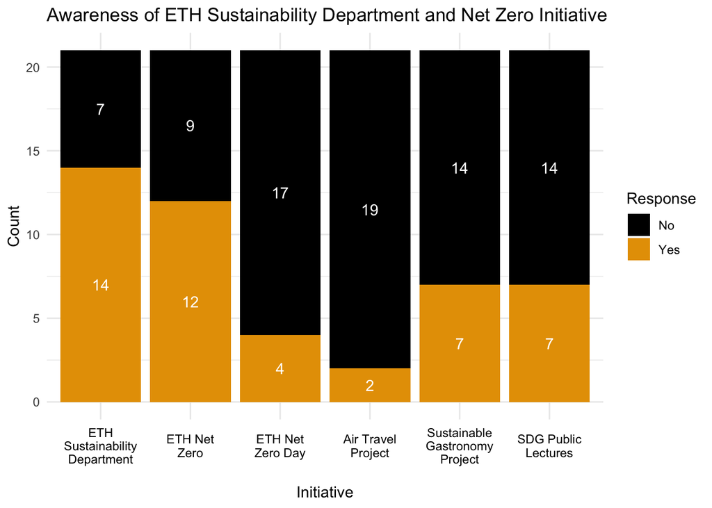

Figure 1: Awareness of the ETH Sustainability Department and its initiatives among ETH domain members.

```r
# data analysis --------------------------------------
initiative_names <- c(
  heard_eth_sus = "ETH Sustainability Department",
  heard_net_zero = "ETH Net Zero",
  heard_net_zero_day = "ETH Net Zero Day",
  heard_air_travel = "Air Travel Project",
  heard_sus_gastronomy = "Sustainable Gastronomy Project",
  heard_sdg_lecture = "SDG Public Lectures"
)

awareness_dep_sus_ini <- eth_dep_sus_visibility_visual %>%
  select(heard_eth_sus, heard_net_zero, heard_net_zero_day, heard_air_travel, heard_sus_gastronomy, heard_sdg_lecture) %>%
  pivot_longer(cols = everything(), names_to = "Initiative", values_to = "Response") %>%
  mutate(Initiative = recode(Initiative, !!!initiative_names)) %>%
  mutate(Initiative = factor(Initiative, levels = initiative_names)) %>%
  group_by(Initiative, Response) %>%
  summarise(Count = n(), .groups = 'drop') %>%
  mutate(Response = factor(Response, levels = c("No", "Yes", "N/A")))

# results display as visualisation --------------------------------------
ggplot(data = awareness_dep_sus_ini, aes(x = Initiative, y = Count, fill = Response)) +
  geom_bar(stat = "identity") +  # Keep the default stacking order
  geom_text(aes(label = Count), position = position_stack(vjust = 0.5), color = "white") +  # Change text color to white
  labs(title = "Awareness of ETH Sustainability Department and Net Zero Initiative",
       x = "Initiative",
       y = "Count",
       fill = "Response") +
  theme_minimal() +
  theme(
    axis.text.x = element_text(color = "black", angle = 0, hjust = 0.5, vjust = 0.5),
    axis.title.x = element_text(margin = margin(t = 15))  # Increase margin at the top of the x-axis title
  ) +
  scale_x_discrete(labels = function(x) str_wrap(x, width = 10)) +
  scale_fill_colorblind()

# save data underlying the table ----------------------
write_csv(awareness_dep_sus_ini, here::here("data/final/awareness_department_initiatives.csv"))
```

In contrast, Figure 2 shows how well-known the initiatives are among people who indicated being familiar with the department’s work.

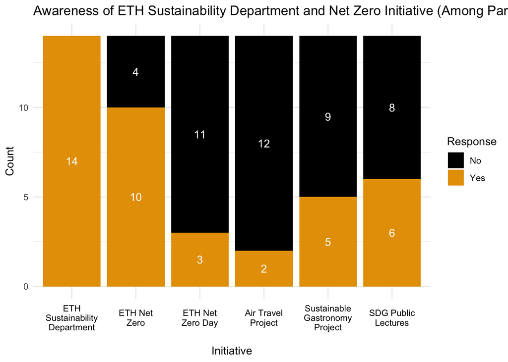

Figure 2: Awareness of the ETH Sustainability Department and its initiatives among ETH domain members who responded Yes to hearing about the Sustainability Department.

```r
# Filter data for participants who responded "Yes" to hearing about the Sustainability Department
awareness_dep_sus_ini_filtered <- eth_dep_sus_visibility_visual %>%
  filter(heard_eth_sus == "Yes") %>%
  select(heard_eth_sus, heard_net_zero, heard_net_zero_day, heard_air_travel, heard_sus_gastronomy, heard_sdg_lecture) %>%
  pivot_longer(cols = everything(), names_to = "Initiative", values_to = "Response") %>%
  mutate(Initiative = recode(Initiative, !!!initiative_names)) %>%
  mutate(Initiative = factor(Initiative, levels = initiative_names)) %>%
  group_by(Initiative, Response) %>%
  summarise(Count = n(), .groups = 'drop') %>%
  mutate(Response = factor(Response, levels = c("No", "Yes", "N/A")))

# results display as visualisation --------------------------------------
ggplot(data = awareness_dep_sus_ini_filtered, aes(x = Initiative, y = Count, fill = Response)) +
  geom_bar(stat = "identity") +  # Keep the default stacking order
  geom_text(aes(label = Count), position = position_stack(vjust = 0.5), color = "white") +  # Change text color to white
  labs(title = "Awareness of ETH Sustainability Department and Net Zero Initiative (Among Participants who Heard about the Sustainability Department)",
       x = "Initiative",
       y = "Count",
       fill = "Response") +
  theme_minimal() +
  theme(
    axis.text.x = element_text(color = "black", angle = 0, hjust = 0.5, vjust = 0.5),
    axis.title.x = element_text(margin = margin(t = 15))  # Increase margin at the top of the x-axis title
  ) +
  scale_x_discrete(labels = function(x) str_wrap(x, width = 10)) +
  scale_fill_colorblind()

# save data underlying the table ----------------------
write_csv(awareness_dep_sus_ini_filtered, here::here("data/final/awareness_department_initiatives_filtered.csv"))
```

To further explore the awareness of ETH members regarding this initiative, additional questions were asked regarding specific ETH Net Zero measures. Specifically, participants were initially asked to assess their familiarity with Net Zero on a scale from “not familiar at all” to “very familiar,” and then which of these measures they had heard of. Figure 3 illustrates that the “Decarbonized Campus” initiative is the most recognized.

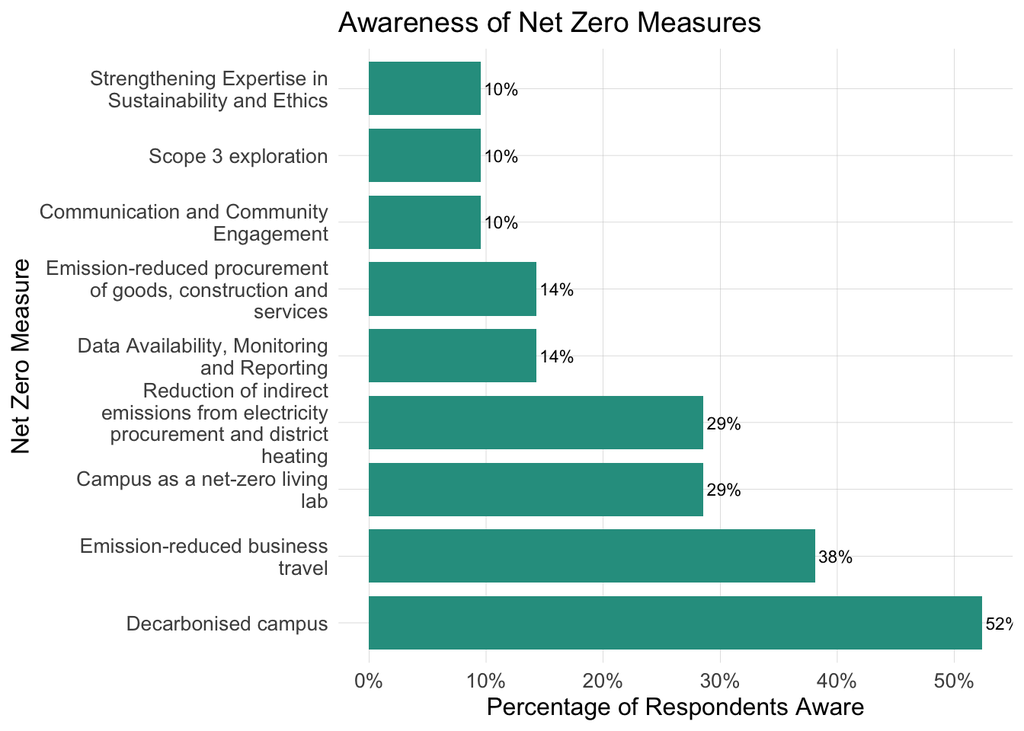

Figure 3: Awareness of Net Zero initiative among ETH domain members.

```r
## What is the awareness of the Net Zero measures among the people that have heard of the Net Zero initiative?
# data analysis --------------------------------------
measure_labels <- c(
  heard_measure_dec_campus = "Decarbonised campus",
  heard_measure_indirect_emissions = "Reduction of indirect emissions from electricity procurement and district heating",
  heard_measure_living_lab = "Campus as a net-zero living lab",
  heard_measure_bus_travel = "Emission-reduced business travel",
  heard_measure_scope3 = "Scope 3 exploration",
  heard_measure_procurement = "Emission-reduced procurement of goods, construction and services",
  heard_measure_community_engage = "Communication and Community Engagement",
  heard_measure_data_monitor = "Data Availability, Monitoring and Reporting",
  heard_measure_expertise = "Strengthening Expertise in Sustainability and Ethics"
)

awareness_net_zero_measures <- eth_dep_sus_visibility_visual %>%
  select(starts_with("heard_measure_")) %>%
  summarise_all(~sum(. == "Yes", na.rm = TRUE) / n()) %>%
  gather(key = "Measure", value = "Percentage") %>%
  mutate(Measure = recode(Measure, !!!measure_labels))

awareness_net_zero_measures <- awareness_net_zero_measures %>%
  mutate(Measure = str_wrap(Measure, width = 30))

# results display as visualisation --------------------------------------
ggplot(awareness_net_zero_measures, aes(x = reorder(Measure, -Percentage), y = Percentage)) +
  geom_bar(stat = "identity", fill = "#2a9d8f", width = 0.8) +  # Adjust bar width and color
  geom_text(aes(
    label = scales::percent(Percentage, accuracy = 1)),
    hjust = -0.1, size = 3, color = "black") +  # Add percentage labels
  labs(title = "Awareness of Net Zero Measures",
       x = "Net Zero Measure",
       y = "Percentage of Respondents Aware") +
  coord_flip() +
  scale_y_continuous(labels = percent_format()) +
  theme_minimal() +
  theme(
    plot.title = element_text(size = 14),
    axis.title.x = element_text(size = 12),
    axis.title.y = element_text(size = 12),
    axis.text.x = element_text(size = 10),
    axis.text.y = element_text(size = 10, hjust = 1),
    panel.grid.major = element_line(linewidth = 0.1, color = "gray80"),
    panel.grid.minor = element_blank(),
  )

# save data underlying the table ----------------------
write_csv(awareness_net_zero_measures, here::here("data/final/awareness_net_zero_measures.csv"))
```

### How visible is the work of the ETH Sustainability Department?

```r
# data analysis --------------------------------------
# interest_sustainability_tbl <- eth_dep_sus_visibility_visual %>%
#   summarize(
#     count = n(),
#     mean = mean(interest_sustainability, na.rm = TRUE),
#     median = median(interest_sustainability, na.rm = TRUE),
#     sd = sd(interest_sustainability, na.rm = TRUE)
#   ) %>%
#   mutate(category = "Personal interest in sustainability and climate change mitigation")

importance_eth_strategy_tbl <- eth_dep_sus_visibility_visual %>%
  summarize(
    count = n(),
    mean = mean(importance_eth_strategy, na.rm = TRUE),
    median = median(importance_eth_strategy, na.rm = TRUE),
    sd = sd(importance_eth_strategy, na.rm = TRUE)
  ) %>%
  mutate(category = "Importance of ETH-wide Sustainability Strategy")

vis_eth_sus_tbl <- eth_dep_sus_visibility_visual %>%
  summarize(
    count = n(),
    mean = mean(vis_eth_sus_work, na.rm = TRUE),
    median = median(vis_eth_sus_work, na.rm = TRUE),
    sd = sd(vis_eth_sus_work, na.rm = TRUE)
  ) %>%
  mutate(category = "Visibility of the ETH Sustainability Department")

summary_table <- bind_rows(
  #interest_sustainability_tbl,
  importance_eth_strategy_tbl,
  vis_eth_sus_tbl
) %>%
  select(category, everything())

# results display as visualisation --------------------------------------
summary_table %>%
  gt() %>%
  tab_header(
    title = "Summary of Participant's Beliefs",
    subtitle = "Importance, and Visibility"
  ) %>%
  cols_label(
    category = "Category",
    count = "Count",
    mean = "Mean",
    median = "Median",
    sd = "Standard Deviation"
  ) %>%
  fmt_missing(
    columns = everything(),
    missing_text = "N/A"
  )
# save data underlying the table ----------------------
#write_csv(interest_sustainability_tbl, "/cloud/project/data/final/interest_sustainability_summary.csv")
write_csv(importance_eth_strategy_tbl, here::here("data/final/importance_eth_strategy_summary.csv"))
write_csv(vis_eth_sus_tbl, here::here("data/final/visibility_eth_sustainability_summary.csv"))
```

Table 1: Summary of participants attitude towards sustainability, an ETH wide sustainability strategy and the perceived visibility

Summary of Participant's Beliefs

Importance, and Visibility

| Category | Count | Mean | Median | Standard Deviation |
| --- | --- | --- | --- | --- |
| Importance of ETH-wide Sustainability Strategy | 21 | 4.85 | 5 | 0.3663475 |
| Visibility of the ETH Sustainability Department | 21 | 2.40 | 2 | 1.1424811 |

### What are the most effective information channels to increase the visibility of the ETH ETH Sustainability Department?

Participants were asked about the information channels through which they would most likely learn about the department’s work. According to Figure 4, the ETH mailinglist and advertisement on campus are the most promising.

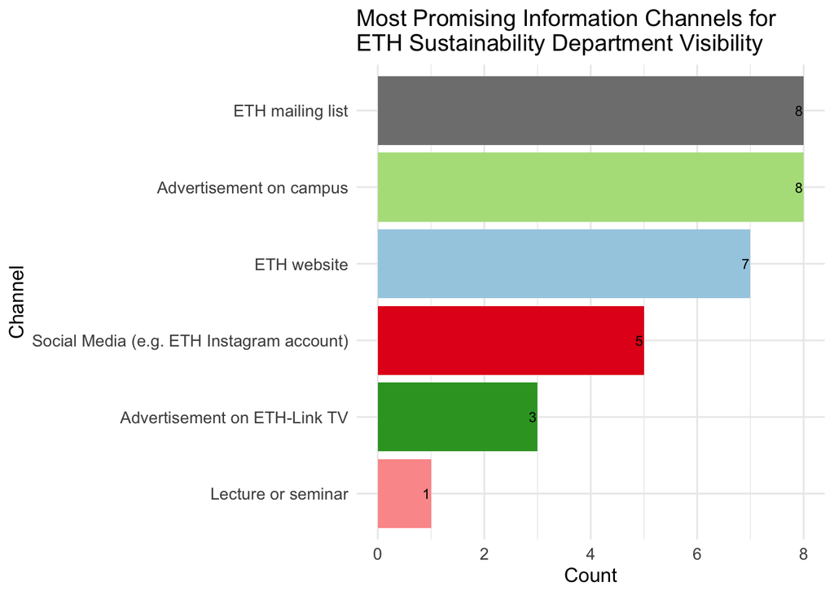

Figure 4: Information diffusion channel considered most promising among ETH domain members.

```r
# Data analysis --------------------------------------
# Data preparation
visibility_data <- eth_dep_sus_visibility_visual %>%
  select(starts_with("notice_"))

# Count the number of TRUE values for each channel
visibility_counts <- visibility_data %>%
  summarise_all(~sum(. == TRUE, na.rm = TRUE))

# Reshape the data for plotting
visibility_counts_long <- visibility_counts %>%
  pivot_longer(cols = everything(), names_to = "Channel", values_to = "Count")

# Label mapping for the channels
channel_labels <- c(
  notice_ETH_main_website = "ETH website",
  notice_ETH_mailing_list = "ETH mailing list",
  notice_Advertisement_on_Campus = "Advertisement on campus",
  notice_ETH_Link_TV = "Advertisement on ETH-Link TV",
  notice_Lectures_and_seminars = "Lecture or seminar",
  notice_Social_Media = "Social Media (e.g. ETH Instagram account)"
)

# Apply the channel labels
visibility_counts_long <- visibility_counts_long %>%
  mutate(Channel = recode(Channel, !!!channel_labels))

# Visualization: Bar plot
ggplot(visibility_counts_long, aes(y = reorder(Channel, Count), x = Count, fill = Channel)) +
  geom_bar(stat = "identity") +
  geom_text(aes(label = Count), hjust = 1.1, color = "black", size = 3) +
  labs(title = "Most Promising Information Channels for \nETH Sustainability Department Visibility",
       x = "Count",
       y = "Channel") +
  theme_minimal() +
  theme(
    plot.title = element_text(size = 14),
    axis.title.x = element_text(size = 12),
    axis.title.y = element_text(size = 12),
    axis.text.x = element_text(size = 10),
    axis.text.y = element_text(size = 10, hjust = 1),
    legend.position = "none"  # Remove the legend
  ) +
  scale_fill_manual(values = c(
    "ETH website" = "#A6CEE3",
    "ETH intranet" = "#1F78B4",
    "Advertisement on campus" = "#B2DF8A",
    "Advertisement on ETH-Link TV" = "#33A02C",
    "Lecture or seminar" = "#FB9A99",
    "Social Media (e.g. ETH Instagram account)" = "#E31A1C"
  ))

# Save data underlying the table
write_csv(visibility_counts_long, here::here("data/final/visibility_counts.csv"))
```

This is contrasted by the most mentioned information source for the ETH Net Zero initiative is “other students/colleagues.” According to Figure 5 most participants heard of the ETH Net Zero initiative through other students and colleagues.

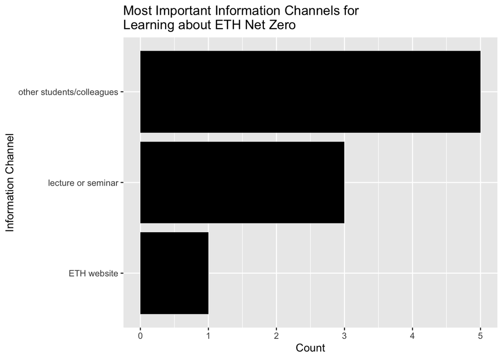

Figure 5: Information diffusion channel of Net Zero Initiative among ETH domain members.

```r
## What information channel was the most effective?
# data analysis --------------------------------------
net_zero_learning <- eth_dep_sus_visibility_visual %>%
  filter(!is.na(learn_net_zero)) %>%
  filter(heard_net_zero == "Yes")

net_zero_info_channel_count <- net_zero_learning %>%
  count(learn_net_zero) %>%
  arrange(desc(n))

# results display as visualisation --------------------------------------
ggplot(net_zero_info_channel_count, aes(x = fct_reorder(learn_net_zero, n), y = n)) +
  geom_bar(stat = "identity", fill = "black") +
  labs(title = "Most Important Information Channels for \nLearning about ETH Net Zero",
       x = "Information Channel",
       y = "Count") +
  coord_flip()

# save data underlying the table ----------------------
write_csv(net_zero_info_channel_count, here::here("data/final/net_zero_info_channel.csv"))
```

# Conclusions

In summary, the following conclusions can be drawn:

- The awareness of the ETH Department for Sustainability among participants is moderate, indicating potential opportunities for enhancing outreach efforts.
- The Net Zero Initiative was identified as the most well-known initiative within the ETH community. Participants heard of the initiative mainly through other students and colleagues.
- Despite the importance of sustainability, the department’s visibility could be better, indicating a need for improved communication and promotional strategies.
- Among the various information diffusion channels considered, the ETH mailing list and advertising the work on campus are the most effective for disseminating information about the department’s activities and initiatives, highlighting its potential for increasing visibility and engagement.

## References

ARE, B. für R. (n.d.). *Nachhaltigkeitsverständnis in der Schweiz*. https://www.are.admin.ch/are/de/home/nachhaltige-entwicklung/internationale-zusammenarbeit/nachhaltigkeitsverstaendnis-in-der-schweiz.html.

ARE, B. für R. (2021). *Strategie Nachhaltige Entwicklung 2030*. Schweizerischer Bundesrat.

Commission mondiale sur l’environnement et le développement (Ed.). (1991). *Our common future*. Oxford university press.

*ETH Sustainability*. (n.d.). https://ethz.ch/en/the-eth-zurich/sustainability/eth-sustainability.html.

United Nations. (2015). *Transforming our World: The 2030 Agenda for Sustainable Development* (Resolution A/RES/70/1). United Nations.